# dRelatório de Análise das Desigualdades Remuneratórias no Executivo Civil Federal

Felix G. Lopez

2026-04-29

# 1 1. Introdução

Esta seção apresenta uma análise exploratória das desigualdades remuneratórias no Executivo Civil Federal brasileiro de 2022 e 2025, com foco na distribuição de rendimentos dentro de grupos ocupacionais classificados segundo a tipologia `classificacao_ipea2026`.

As medidas centrais, nesta seção, são os **coeficientes de Gini**, indicador clássico de desigualdade distributiva, no qual valores mais próximos de zero indicam maior igualdade e valores mais elevados sugerem maior concentração interna dos rendimentos. Adota-se também estatísticas básicas, tais como intervaloes interquartis, médias e medianas.

# 2 2. Leitura da base

# 3 3. Diagnóstico dos nomes das colunas

## 3.1 Nomes originais

| colunas_originais |
| --- |
| grafico_gêni |
| ano |
| mes |
| classificacao_ipea2026 |
| coeficiênte_gêni |
| servidores |
| vinculos |
| qtde_cargos |
| media_vr_rendim |
| stddev_vr_rendim |
| minimo_vr_rendim |
| perc25_vr_rendim |
| perc50_vr_rendim |
| perc75_vr_rendim |
| maximo_vr_rendim |
| media_vr_remun |
| stddev_vr_remun |
| minimo_vr_remun |
| perc25_vr_remun |
| perc50_vr_remun |
| perc75_vr_remun |
| maximo_vr_remun |
| media_vr_liquido |
| stddev_vr_liquido |
| minimo_vr_liquido |
| perc25_vr_liquido |
| perc50_vr_liquido |
| perc75_vr_liquido |
| maximo_vr_liquido |

## 3.2 a Nomes após padronização com `clean_names()`

| colunas_limpas |
| --- |
| grafico_geni |
| ano |
| mes |
| classificacao_ipea2026 |
| gini |
| servidores |
| vinculos |
| qtde_cargos |
| media_vr_rendim |
| stddev_vr_rendim |
| minimo_vr_rendim |
| perc25_vr_rendim |
| perc50_vr_rendim |
| perc75_vr_rendim |
| maximo_vr_rendim |
| media_vr_remun |
| stddev_vr_remun |
| minimo_vr_remun |
| perc25_vr_remun |
| perc50_vr_remun |
| perc75_vr_remun |
| maximo_vr_remun |
| media_vr_liquido |
| stddev_vr_liquido |
| minimo_vr_liquido |
| perc25_vr_liquido |
| perc50_vr_liquido |
| perc75_vr_liquido |
| maximo_vr_liquido |

# 4 4. Checagem automática das colunas

| variavel_analitica | coluna_encontrada |
| --- | --- |
| ano | ano |
| mes | mes |
| grupo | classificacao_ipea2026 |
| gini | gini |
| servidores | servidores |
| vinculos | vinculos |
| qtde_cargos | qtde_cargos |
| media_vr_rendim | media_vr_rendim |
| perc25_vr_rendim | perc25_vr_rendim |
| perc50_vr_rendim | perc50_vr_rendim |
| perc75_vr_rendim | perc75_vr_rendim |
| maximo_vr_rendim | maximo_vr_rendim |

## 4.1 Colunas ausentes

```
## Todas as colunas essenciais foram localizadas com sucesso.
```

# 5 5. Padronização interna dos nomes analíticos

| colunas_finais |
| --- |
| grafico_geni |
| ano |
| mes |
| grupo |
| gini |
| servidores |
| vinculos |
| qtde_cargos |
| media_vr_rendim |
| stddev_vr_rendim |
| minimo_vr_rendim |
| perc25_vr_rendim |
| perc50_vr_rendim |
| perc75_vr_rendim |
| maximo_vr_rendim |
| media_vr_remun |
| stddev_vr_remun |
| minimo_vr_remun |
| perc25_vr_remun |
| perc50_vr_remun |
| perc75_vr_remun |
| maximo_vr_remun |
| media_vr_liquido |
| stddev_vr_liquido |
| minimo_vr_liquido |
| perc25_vr_liquido |
| perc50_vr_liquido |
| perc75_vr_liquido |
| maximo_vr_liquido |

# 6 6. Estrutura geral da base

| Observacoes | Variaveis | Anos | Grupos |
| --- | --- | --- | --- |
| 84 | 29 | 4 | 21 |

# 7 7. Diagnóstico de completude

| variavel | n_missing |
| --- | --- |
| stddev_vr_rendim | 4 |
| stddev_vr_remun | 4 |
| stddev_vr_liquido | 4 |
| grafico_geni | 0 |
| ano | 0 |
| mes | 0 |
| grupo | 0 |
| gini | 0 |
| servidores | 0 |
| vinculos | 0 |
| qtde_cargos | 0 |
| media_vr_rendim | 0 |
| minimo_vr_rendim | 0 |
| perc25_vr_rendim | 0 |
| perc50_vr_rendim | 0 |
| perc75_vr_rendim | 0 |
| maximo_vr_rendim | 0 |
| media_vr_remun | 0 |
| minimo_vr_remun | 0 |
| perc25_vr_remun | 0 |
| perc50_vr_remun | 0 |
| perc75_vr_remun | 0 |
| maximo_vr_remun | 0 |
| media_vr_liquido | 0 |
| minimo_vr_liquido | 0 |
| perc25_vr_liquido | 0 |
| perc50_vr_liquido | 0 |
| perc75_vr_liquido | 0 |
| maximo_vr_liquido | 0 |

# 8 8. Indicadores derivados

```
## Indicadores derivados criados com sucesso.
```

# 9 9. Total de vínculos por grupo

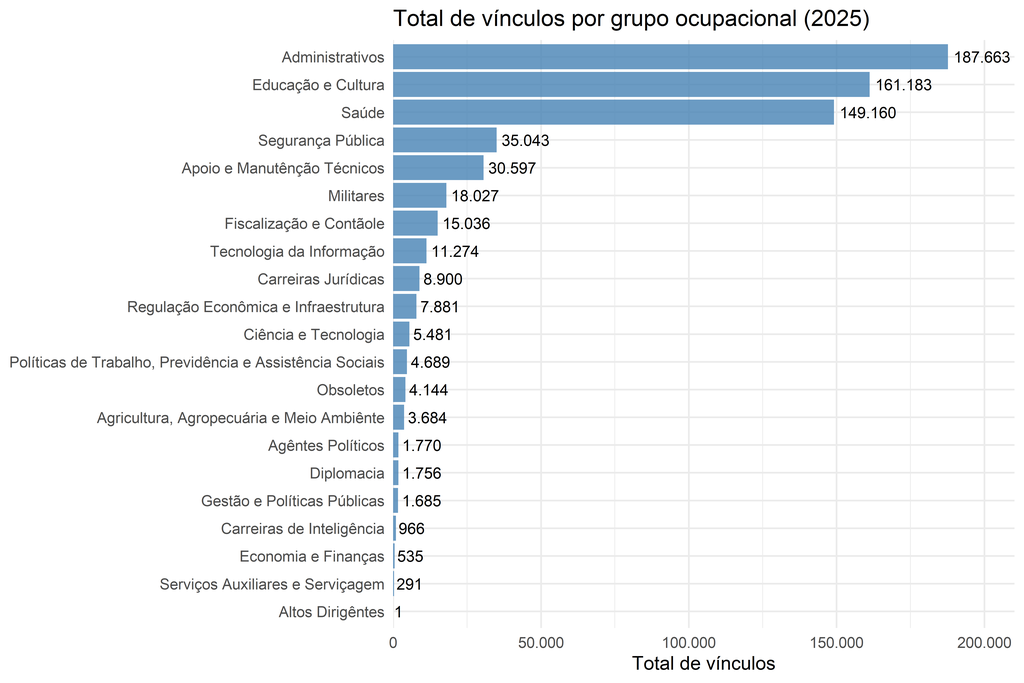

# 10 12 A1 boxplots

Os boxplots da remuneração em 2025 evidenciam heterogeneidade entre grupos ocupacionais e também dentro deles. Alguns segmentos combinam elevados níveis salariais com grande dispersão interna e máximos muito distantes do restante da distribuição, sugerindo estruturas hierárquicas fortemente estratificadas (em termos remuneratórios, pelo menos). Outros grupos apresentam caixas mais compactas, indicando remuneração mais homogênea e trajetórias salariais menos desiguais. O resultado confirma que a desigualdade remuneratória no setor público federal opera simultaneamente entre e dentro dos agrupamentos ocupacionais.

No topo da estrutura remuneratória permanecem grupos como Gestão e Políticas Públicas, Economia e Finanças, Fiscalização e Controle, Carreiras Jurídicas, Ciência e Tecnologia e Carreiras de Inteligência. Esses segmentos apresentam medianas e quartis superiores elevados.

Em posição intermediária situam-se grupos como Segurança Pública, Educação e Cultura, Regulação Econômica e Infraestrutura, Políticas de Trabalho, Previdência e Assistência Social, Militares e Agentes Políticos.

Na base da estrutura aparecem grupos como Administrativos, Tecnologia da Informação, Saúde, Apoio e Manutenção Técnicos, Serviços Auxiliares e Serviçagem, além dos cargos classificados como Obsoletos. Isso indica que funções operacionais, rotinas administrativas e parte das atividades de suporte institucional são remuneradas em patamar inferior ao núcleo tecnocrático estatal. Em outras palavras, a sustentação cotidiana da máquina pública repousa em grande medida sobre segmentos comparativamente menos valorizados.

O gráfico também revela diferenças expressivas de desigualdade interna. Em Ciência e Tecnologia, por exemplo, a caixa é larga e o valor máximo bastante elevado, sugerindo coexistência de posições muito distintas dentro do mesmo agrupamento. É plausível que convivam nesse segmento carreiras técnicas médias, pesquisadores seniores, especialistas altamente titulados e funções estratégicas de direção científica. A desigualdade não decorre apenas do nível salarial médio, mas da heterogeneidade interna.

Carreiras Jurídicas também exibem elevado nível remuneratório e forte distância entre o centro da distribuição e o topo. Isso sugere progressões relevantes, adicionais específicos e hierarquias internas grandes. O mesmo padrão aparece, em menor grau, em alguns grupos administrativos: embora a mediana seja mais modesta, a presença de máximos muito distantes indica que dentro de agregados administrativos convivem posições bastante distintas, possivelmente em razão da reunião de carreiras diversas sob uma mesma categoria ampla.

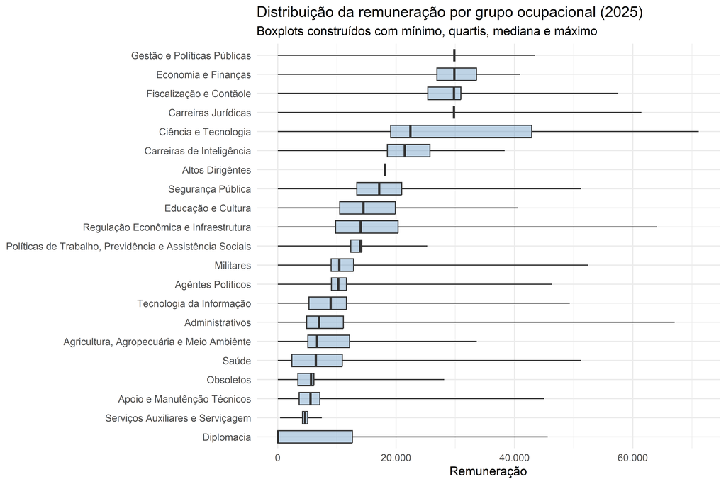

# 11 9. Índice de Gini no Executivo Federal (2022-2025)

| ano | gini_medio |
| --- | --- |
| 2022 | 0.2285714 |
| 2023 | 0.2223810 |
| 2024 | 0.2276190 |
| 2025 | 0.2266667 |

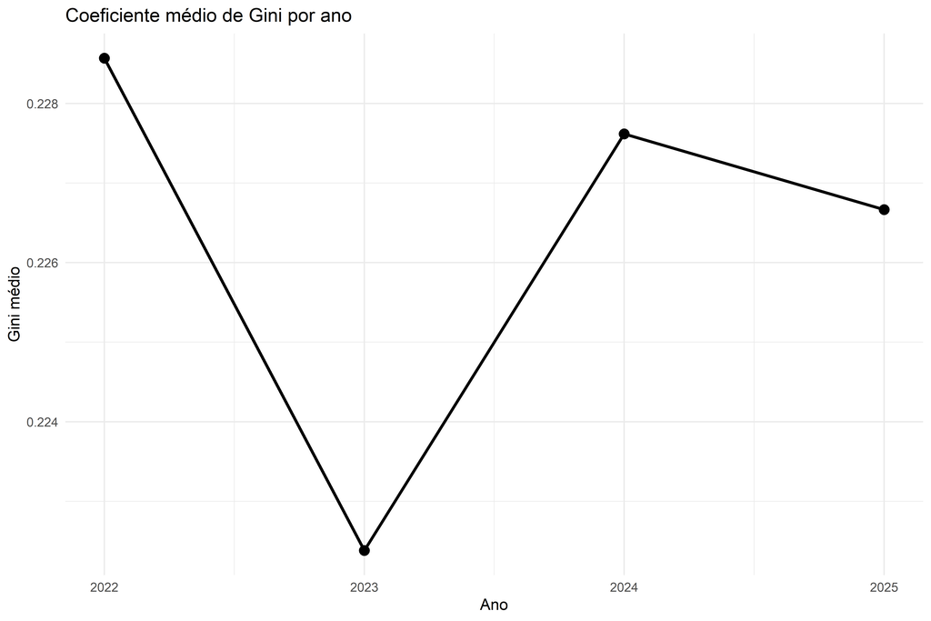

# 12 10. Desigualdade por grupos ocupacionais

## 12.1 Gini em 2025

| grupo | gini |
| --- | --- |
| Diplomacia | 0.73 |
| Saúde | 0.47 |
| Administrativos | 0.35 |
| Tecnologia da Informação | 0.33 |
| Agricultura, Agropecuária e Meio Ambiênte | 0.28 |
| Apoio e Manutênção Técnicos | 0.28 |
| Ciência e Tecnologia | 0.27 |
| Educação e Cultura | 0.25 |
| Regulação Econômica e Infraestrutura | 0.25 |
| Segurança Pública | 0.21 |
| Militares | 0.19 |
| Carreiras de Inteligência | 0.18 |
| Obsoletos | 0.18 |
| Agêntes Políticos | 0.16 |
| Economia e Finanças | 0.16 |
| Fiscalização e Contãole | 0.12 |
| Gestão e Políticas Públicas | 0.11 |
| Serviços Auxiliares e Serviçagem | 0.09 |
| Políticas de Trabalho, Previdência e Assistência Sociais | 0.08 |
| Carreiras Jurídicas | 0.07 |

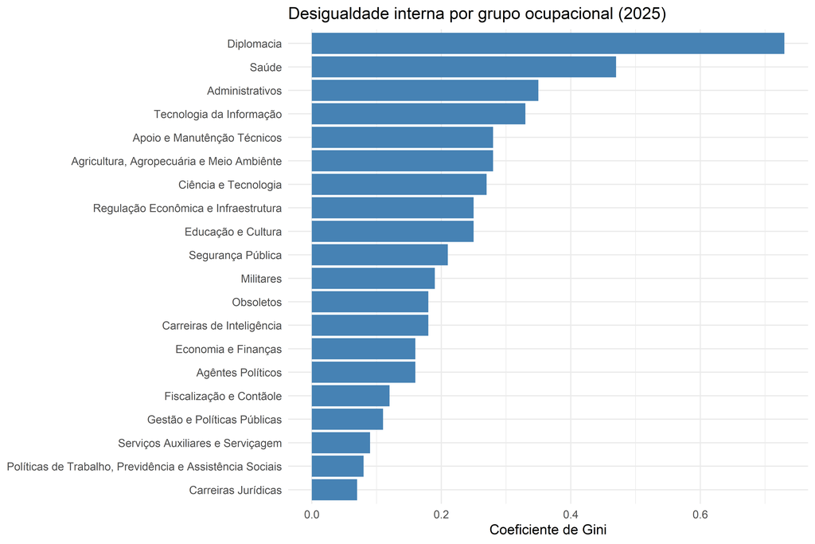